# Nature Dependence through Value Chains | Norway

Magnus Merkle (SSB), with Marte Lindseth (SSB) and Kristine Grimsrud (SSB)

Naturregnskapsprosjekt, 27. October 2025

# Changelog

Changes since version 1:

- added EXIOBASE-based analysis for comparison

# Abstract and Limitation

# 1. Filepaths and Functions

```r
# make space
rm(list = ls())
# packages
library(dplyr)
library(tidyr)
library(openxlsx)
library(readxl)
library(Rfast)
library(ggplot2)
# filepath to the wd
wfp<-file.path("C:","Users","muk",
               paste0("OneDrive - Statistisk sentralbyr","\U00E5"),
               "Projects","Naturregnskap","Verdikjeder","analysis")
# filepath to GLORIA
gfp<-file.path("C:","Users","muk",
               paste0("OneDrive - Statistisk sentralbyr","\U00E5"),
               "data","GLORIA","v59")
# file path to ENCORE
nfp<-file.path("C:","Users","muk",
               paste0("OneDrive - Statistisk sentralbyr","\U00E5"),
               "data","ENCORE","Updated ENCORE knowledge base September 2025",
               "ENCORE files")
# file path to EXIOBASE
efp<-file.path("C:","Users","muk",
               paste0("OneDrive - Statistisk sentralbyr","\U00E5"),
               "data","EXIOBASE")
```

# 2. Get data

In this section we run scripts to import data, aggregate it to the desired resolution, and match it in preparation for the subsequent analysis.

## 2.1 Import and Format GLORIA

Here we import GLORIA multi-regional input-output data at the desired country-sector resolution. We loop across years, running an external script containing IO dataread and aggregation processes.

```r
# dir.create(file.path(wfp,"dataimport","tmpdir"))
#
# timestep<-"1990"
# qcode<-"20231117"
# mcode<-"20240110"
# source(file.path(wfp,"dataimport","import_gloria_script.R"))
#
# timestep<-"1995"
# qcode<-"20231117"
# mcode<-"20240110"
# source(file.path(wfp,"dataimport","import_gloria_script.R"))
#
# timestep<-"2000"
# qcode<-"20231117"
# mcode<-"20240111"
# source(file.path(wfp,"dataimport","import_gloria_script.R"))
#
# timestep<-"2005"
# qcode<-"20231117"
# mcode<-"20240111"
# source(file.path(wfp,"dataimport","import_gloria_script.R"))
#
# timestep<-"2010"
# qcode<-"20231117"
# mcode<-"20240111"
# source(file.path(wfp,"dataimport","import_gloria_script.R"))
#
# timestep<-"2015"
# qcode<-"20231117"
# mcode<-"20240111"
# source(file.path(wfp,"dataimport","import_gloria_script.R"))
#
# timestep<-"2020"
# qcode<-"20231117"
# mcode<-"20240111"
# source(file.path(wfp,"dataimport","import_gloria_script.R"))
#
# timestep<-"2025"
# qcode<-"20231117"
# mcode<-"20240111"
# source(file.path(wfp,"dataimport","import_gloria_script.R"))

# clean up environment
rm(list=ls()[! ls() %in% c("nfp","efp","wfp")])
```

## 2.2 Import and Format EXIOBASE

Just like H et al we import the 2022 tables. We make one adjustment that is necessary in order to avoid negative value added cases. Negative value added happens when intermediate input to a sector exceeds its total output. We aggregate all sectors withing processing of meat (i.e. no differentiation between processing of poultry, cattle, etc) and we aggregate meat animals nec together with animal products nec. This step should not have any impact on the result, because nature dependency scores for the aggregated sectors do not vary. Our aggregation implies that we work with a 159 sector resolution of EXIOBASE.

```r
# dir.create(file.path(wfp,"dataimport","tmpdir"))

# timestep <- "2022"
# source(file.path(wfp,"dataimport","import_exiobase_script.R"))

# clean up environment
rm(list=ls()[! ls() %in% c("nfp","wfp")])
```

## 2.3 Import and Format ENCORE for GLORIA

Here we import ENCORE nature dependency data. We also calculate consolidated dependency scores just as Hirschbuehl et al. do in their study.

To revisit: currently we assume that ND and N/A imply zero dependency, and this pulls results downwards. An alternative could be to define them as NA, then they would “not count” in the calculation of averages. Not sure what H. et al. did.

```r
# import data
materd<-read.csv(file.path(nfp,"06. Dependency mat ratings.csv"))

# first reformat for easier quantification
materd<-materd %>% pivot_longer(-c("ISIC.Unique.code","ISIC.Section",
                                   "ISIC.Division","ISIC.Group","ISIC.Class",
                                   "ISIC.level.used.for.analysis"),
                                names_to="ecosystem_service",
                                values_to="rating")

# then make it numeric so we can compute averages
# MM I assume that "ND" and "N/A" imply zero dependency. To revisit later.
materd['rating_n']<-NA
materd$rating_n[materd$rating=="VL"]<-1
materd$rating_n[materd$rating=="L"]<-2
materd$rating_n[materd$rating=="M"]<-3
materd$rating_n[materd$rating=="H"]<-4
materd$rating_n[materd$rating=="VH"]<-5
materd$rating_n[materd$rating=="ND"]<-0
materd$rating_n[materd$rating=="N/A"]<-0

# now we want "consolidated dependency scores"
# so first pivot wider again and remove the old rating variable
materd <- materd %>% select(-rating) %>%
  pivot_wider(names_from = ecosystem_service,values_from=rating_n)

# Then we compute the individual components of the consolidated score
# number of different sectoral ecosystem dependencies
materd['score1']<-NA
# mean materiality rating across all
materd['score2']<-NA
# maxiumum strength across the individual dependencies
materd['score3']<-NA

# implement as loop across sectors
# 25 different ecosystem services in colums 7 to 31 in our dataset
for(i in 1:nrow(materd)){
  # count how many of the values are larger than zero
  materd$score1[i]<-sum(materd[i,7:31]>0)
  # generate the mean
  materd$score2[i]<-mean(as.numeric(materd[i,7:31]))
  # identify the largest value
  materd$score3[i]<-max(materd[i,7:31])
}
rm(i)

# and then we compute the consolidate score just like H et al
materd['c_score']<-((1/3)*materd$score1*(5/25))+((1/3)*materd$score2)+((1/3)*materd$score3)
# let's only keep the consolidated score for now
materd <- materd %>% select("ISIC.Unique.code","ISIC.Section","ISIC.Division",
                            "ISIC.Group","ISIC.Class",
                            "ISIC.level.used.for.analysis","c_score")
```

## 2.4 Map ENCORE to GLORIA

Here we now map ENCORE to GLORIA and compute nature dependency scores for each GLORIA sector.

```r
# first get a vector of GLORIA sector names
sq <- read_excel(file.path(wfp,"dataimport","GLORIA_ReadMe_059_adj.xlsx"),
                         sheet = "Sectors") %>%
  select(Sector_names) %>%
  as.matrix() %>% as.character()

# import concordance data
concd <- read.xlsx(
  file.path(wfp,"GLORIA_ISICr4_ENCORE_concordance.xlsx"),
  sheet="Sectors")
# make it a list
concl<-list()
for(i in 1:nrow(concd)){
  concl[[i]]<- trimws(as.character(unlist(strsplit(concd$ENCORE_ISIC_codes[i], ";"))))
}
# trimws is required because we get leading spaces otherwise...
names(concl)<-concd$Sector_names
# so now we have for each GLORIA sector the vector of unique ENCORE-ISIC-sectors.

# then make a dataframe where we calculate the average dependency score for each GLORIA sector
dfc<-as.data.frame(cbind(sq,NA))
colnames(dfc)<-c("sq","dependency_score")

# then loop across to get the average score for each GLORIA sector
for(i in 1:nrow(dfc)){
  dfc$dependency_score[i]<-mean(materd$c_score[materd$ISIC.Unique.code %in% concl[[i]]])
}
# for some reason the mean scores are saved as characters. MM check later.
dfc$dependency_score <- as.numeric(dfc$dependency_score)

# clean up
rm(concd,concl,materd,i)
```

## 2.5 Map ENCORE to EXIOBASE

This step we do not need to do, because we can just take the data ready from H et al. It is in their appendix (table A.9).

```r
# all in one excel sheet copied from the appendix
exdfc<-read_excel(file.path(wfp,"exiobase_sector_nature_dep.xlsx"),sheet="dep") %>%
  select(c(Sector_name,ENCORE_2024)) %>%
  mutate(ENCORE_2024 = as.numeric(ENCORE_2024)) %>%
  rename(sq=Sector_name)
```

## 2.6 Dependency Threholds

Hirschbuehl et al. adopt the following ENCORE dependency ratings:

- A score below 2.25 is LOW
- A score between 2.25 and 3.25 is MEDIUM
- A score above 3.25 is HIGH We adopt the same thresholds here.

```r
# define rating for gloria
dfc['dependency_rating']<-NA
dfc$dependency_rating[dfc$dependency_score<2.25] <- "LOW"
dfc$dependency_rating[dfc$dependency_score>3.25] <- "HIGH"
dfc$dependency_rating[dfc$dependency_score>=2.25 & dfc$dependency_score<=3.25] <- "MEDIUM"

# define rating for exionbase
exdfc['dependency_rating']<-NA
exdfc$dependency_rating[exdfc$ENCORE_2024<2.25] <- "LOW"
exdfc$dependency_rating[exdfc$ENCORE_2024>3.25] <- "HIGH"
exdfc$dependency_rating[exdfc$ENCORE_2024>=2.25 & exdfc$ENCORE_2024<=3.25] <- "MEDIUM"
```

# 3. Compute Direct and Supply Chain Value Added

## 3.1 Overview

This step involves a little bit of linear algebra, which is well documented by Hirschbuehl et al. The inputs to this process are the IO coefficients matrix $A$, the matrix of value-added shares $\hat{V}$, and the final demand vector $y$.

## 3.2 Function for GLORIA

We create a function that we can then run for each year we are interested in.

```r
# make a function
va_compute <- function(yr){
#### Step 1: Import formatted GLORIA data
load(file.path(wfp,"dataimport","tmpdir",paste0("gloria_",yr,".RData")))

#### Step 2: Create total output
# First the rowsums of the transaction matrix
aggz<-z %*% matrix(rep(1,times=ncol(z)),ncol=1)
# Then the rowsums of the final demand matrix
aggy<-y %*% matrix(rep(1,times=ncol(y)),ncol=1)
# Then the sum of both for total outpt
x<-aggz + aggy
# clean up
rm(aggz)

#### Step 3: Create technical coefficients matrix
# first the inverse
xinv<-x^-1
xinvv<-as.vector(xinv)
xinvvd<-diag(xinvv)
# then the matrix
a <- mat.mult(z,xinvvd)
# clean up
rm(xinv,xinvv,xinvvd)
# check results.
# check if any NAs. If so, then thats probably due to zero outputs. Confirm. Then turn NAs into zeros.
zocases<-paste(round(100*length(a[is.na(a)])/length(a),digits = 2),"%",sep=" ")
a[is.na(a)]<-0

#### Step 4: Calculate Leontief matrix
# first we need an identity matrix
I<-diag(ncol(z))
# then I minus the technical coefficients matrix
I_a<-I-a
# then the leontief inverse
leo<-solve(I_a)
# add labels
colnames(leo)<-colnames(z)
rownames(leo)<-rownames(z)
# clean up
rm(I_a)

#### Step 5: Create value-added shares (following H et al.)
# I create a unity vector for the aggregation operations
# premultiplication with a rowvector of ones gives sums across rows (columnsums)
# postmultiplication with a columnvector of ones gives sums across columns (rowsums)
u <- matrix(rep(1,times=nrow(z)),ncol=1)
# Identity matrix minus the diagonalised sum across rows of A.
vh <- I - diag(as.vector(t(u) %*% a))
# clean up
rm(I,v,a,z)

#### Step 6: Create diagonalised demand vector
yh <- diag(as.vector(aggy))

#### Step 7: Compute the Tv matrix (following H et al.)
Tv <- vh %*% leo %*% yh

#### Step 8: Compute direct value added (following H et al.)
# this is just a subsetting process. We need the diagonal elements
# I do this by using the hadamard product with the identity matrix
tvd <- (Tv * diag(as.vector(u))) %*% u
# Subsetting Norway from this
tvdn<- as.vector(tvd)[which(fcq=="Norway")]

#### Step 9: Compute upstream value added (following H et al.)
# this is just a subsetting process. Sum along columns (across rows) and substract tvd
uu<-matrix(data=0,nrow=nrow(Tv),ncol=ncol(Tv))
uu[,which(fcq=="Norway")]<-1
# blank out diagonal
diag(uu)<-0
# apply to Tv (hadamard)
tvu <- Tv * uu
# keep only relevant columns
tvun <- tvu[,which(fcq=="Norway")]
# add labels
tvun <- as.data.frame(cbind(fcq,fsq,tvun))
colnames(tvun)<-c("fcq","fsq",sq)
# clean up
rm(uu,tvu)

#### Step 10: Compute downstream value added (following H et al.)
# this is just a subsetting process. Sum along rows (across columns) and substract tvd
uf<-matrix(data=0,nrow=nrow(Tv),ncol=ncol(Tv))
uf[which(fcq=="Norway"),]<-1
# blank out diagonal
diag(uf)<-0
# apply to Tv (hadamard)
tvf <- Tv * uf
# keep only relevant rows
tvfn <- tvf[which(fcq=="Norway"),]
# transpose and then add labels
tvfn <- t(tvfn)
tvfn <- as.data.frame(cbind(fcq,fsq,tvfn))
colnames(tvfn)<-c("fcq","fsq",sq)
# clean up
rm(uf,tvf)

#### Step 11: Put all into a dataframe
tvun['scope']<-"upstream"
tvfn['scope']<-"downstream"
# move together and pivot
df<-rbind(tvun,tvfn)
df <- df %>% pivot_longer(-c(scope,fcq,fsq),names_to = "sector",values_to = "va")
# add direct
dd<-as.data.frame(matrix(ncol=ncol(df),nrow=length(tvdn)))
colnames(dd)<-colnames(df)
dd$scope <- "direct"
dd$sector <- unique(fsq)
dd$fsq <- unique(fsq)
dd$fcq <- "Norway"
dd$va <- tvdn
# and join with upstream and downstream accounts
da <- rbind(dd,df)
da['year'] <- yr
da['zocases'] <- zocases
# make sure value added is saved as numeric variable
da$va <- as.numeric(da$va)
# clean up
rm(aggy,dd,df,leo,Tv,tvd,u,vh,x,y,yh,yq,zq,fcq,fsq,tvdn,zocases)
# return result
return(da)
}
```

## 3.3 Run for GLORIA

Here we loop across years.

```r
# then run the function across years
val<-list()
yrs<-seq(1990,2025,5)
for(l in 1:length(yrs)){
  val[[l]] <- va_compute(yrs[l])
}
vad <- do.call("rbind",val)
rm(val,l,sq)
```

## 3.4 Run for EXIOBASE

Only a single year, no looping required. Same steps as with GLORIA.

```r
#### Step 1: Import formatted EXIOBASE data
yr=2022
load(file.path(wfp,"dataimport","tmpdir",paste0("exiobase_",yr,".RData")))

#### Step 2: Create total output
# First the rowsums of the transaction matrix
aggz<-z %*% matrix(rep(1,times=ncol(z)),ncol=1)
# Then the rowsums of the final demand matrix
aggy<-y %*% matrix(rep(1,times=ncol(y)),ncol=1)
# Then the sum of both for total outpt
x<-aggz + aggy
# clean up
rm(aggz)

#### Step 3: Create technical coefficients matrix
# first the inverse
xinv<-x^-1
xinvv<-as.vector(xinv)
xinvvd<-diag(xinvv)
# then the matrix
a <- mat.mult(z,xinvvd)
# clean up
rm(xinv,xinvv,xinvvd)
# check results.
# check if any NAs. If so, then thats probably due to zero outputs. Confirm. Then turn NAs into zeros.
zocases<-paste(round(100*length(a[is.na(a)])/length(a),digits = 2),"%",sep=" ")
a[is.na(a)]<-0

#### Step 4: Calculate Leontief matrix
# first we need an identity matrix
I<-diag(ncol(z))
# then I minus the technical coefficients matrix
I_a<-I-a
# then the leontief inverse
leo<-solve(I_a)
# add labels
colnames(leo)<-colnames(z)
rownames(leo)<-rownames(z)
# clean up
rm(I_a)

#### Step 5: Create value-added shares (following H et al.)
# I create a unity vector for the aggregation operations
# premultiplication with a rowvector of ones gives sums across rows (columnsums)
# postmultiplication with a columnvector of ones gives sums across columns (rowsums)
u <- matrix(rep(1,times=nrow(z)),ncol=1)
# Identity matrix minus the diagonalised sum across rows of A.
vh <- I - diag(as.vector(t(u) %*% a))
# clean up
rm(I,v,a,z)

###################
#### Step 6: Create diagonalised demand vector
yh <- diag(as.vector(aggy))

#### Step 7: Compute the Tv matrix (following H et al.)
Tv <- vh %*% leo %*% yh

#### Step 8: Compute direct value added (following H et al.)
# this is just a subsetting process. We need the diagonal elements
# I do this by using the hadamard product with the identity matrix
tvd <- (Tv * diag(as.vector(u))) %*% u
# Subsetting Norway from this
tvdn<- as.vector(tvd)[which(fcq=="Norway")]

#### Step 9: Compute upstream value added (following H et al.)
# this is just a subsetting process. Sum along columns (across rows) and substract tvd
uu<-matrix(data=0,nrow=nrow(Tv),ncol=ncol(Tv))
uu[,which(fcq=="Norway")]<-1
# blank out diagonal
diag(uu)<-0
# apply to Tv (hadamard)
tvu <- Tv * uu
# keep only relevant columns
tvun <- tvu[,which(fcq=="Norway")]
# add labels
tvun <- as.data.frame(cbind(fcq,fsq,tvun))
colnames(tvun)<-c("fcq","fsq",unique(fsq))
# clean up
rm(uu,tvu)

#### Step 10: Compute downstream value added (following H et al.)
# this is just a subsetting process. Sum along rows (across columns) and substract tvd
uf<-matrix(data=0,nrow=nrow(Tv),ncol=ncol(Tv))
uf[which(fcq=="Norway"),]<-1
# blank out diagonal
diag(uf)<-0
# apply to Tv (hadamard)
tvf <- Tv * uf
# keep only relevant rows
tvfn <- tvf[which(fcq=="Norway"),]
# transpose and then add labels
tvfn <- t(tvfn)
tvfn <- as.data.frame(cbind(fcq,fsq,tvfn))
colnames(tvfn)<-c("fcq","fsq",unique(fsq))
# clean up
rm(uf,tvf)

#### Step 11: Put all into a dataframe
tvun['scope']<-"upstream"
tvfn['scope']<-"downstream"
# move together and pivot
df<-rbind(tvun,tvfn)
df <- df %>% pivot_longer(-c(scope,fcq,fsq),names_to = "sector",values_to = "va")
# add direct
dd<-as.data.frame(matrix(ncol=ncol(df),nrow=length(tvdn)))
colnames(dd)<-colnames(df)
dd$scope <- "direct"
dd$sector <- unique(fsq)
dd$fsq <- unique(fsq)
dd$fcq <- "Norway"
dd$va <- tvdn
# and join with upstream and downstream accounts
de <- rbind(dd,df)
de['year'] <- yr
de['zocases'] <- zocases
# make sure value added is saved as numeric variable
de$va <- as.numeric(de$va)
# clean up
rm(aggy,dd,df,leo,Tv,tvd,u,vh,x,y,yh,yq,zq,fcq,fsq,tvdn,zocases)
# naming similar to GLORIA
vade<-de
vade['year']<-yr
rm(de,yr)
```

# 4. Compute Disaggregated Nature Dependency Accounts

Now here is where we use the disaggregated value added data from step 3 to compute nature dependency for each sector of interest. Hirschbuehl et al. aggregate their sectors to a 23 sector classification. We do the same, with one minor difference for the GLORIA-based version: we group insurance and asset management together with banking and capital markets (because GLORIA does not allow distinguishing between two sectors here).

## 4.1 Function for GLORIA

We’ll use a function again which we can then apply to loop across years

```r
depend_compute<-function(yr){
## here is our aggregation dataframe
adf <- read_excel(file.path(wfp,"dataimport","GLORIA_ReadMe_059_adj.xlsx"),
                  sheet = "Sectors")
# We need a list giving us the sectors in each category
agl<-list()
for(i in 1:max(adf$AGG_sector,na.rm=T)){
  # data structure
  agl[[i]]<-list()
  agl[[i]] <- list(HIGH = NULL, MEDIUM = NULL, LOW = NULL)
  # high dep sectors
  vec<-dfc %>% filter(sq %in% adf$Sector_names[adf$AGG_sector_match==i]) %>%
    filter(dependency_rating=="HIGH") %>%
    select(sq) %>% as.matrix() %>% as.vector()
  agl[[i]][["HIGH"]] <- if (length(vec) == 0) NULL else vec
  rm(vec)
  # medium dep sectors
  vec<-dfc %>% filter(sq %in% adf$Sector_names[adf$AGG_sector_match==i]) %>%
    filter(dependency_rating=="MEDIUM") %>%
    select(sq) %>% as.matrix() %>% as.vector()
  agl[[i]][["MEDIUM"]] <- if (length(vec) == 0) NULL else vec
  rm(vec)
  # low dep sectors
  vec<-dfc %>% filter(sq %in% adf$Sector_names[adf$AGG_sector_match==i]) %>%
    filter(dependency_rating=="LOW") %>%
    select(sq) %>% as.matrix() %>% as.vector()
  agl[[i]][["LOW"]] <- if (length(vec) == 0) NULL else vec
  rm(vec)
}
names(agl)<-adf$AGG_sector_name[1:length(agl)]

# start with direct dependency
dd<-as.data.frame(matrix(nrow=max(adf$AGG_sector,na.rm=T),ncol=8))
colnames(dd)<-c("year","scope","region","sector","va","low_dep_va","medium_dep_va","high_dep_va")
dd$year <- yr
dd$scope <- "direct"
dd$region <- "Norway"
dd$sector <- adf$AGG_sector_name[1:max(adf$AGG_sector,na.rm=T)]
# loop across sectors
for(i in 1:nrow(dd)){
  # first total value added
  dd$va[i] <- sum(vad$va[vad$year==yr & vad$scope=="direct" & vad$sector %in% adf$Sector_names[adf$AGG_sector_match==i]])
  dd$low_dep_va[i] <- sum(vad$va[vad$year==yr & vad$scope=="direct" & vad$fsq %in% agl[[i]][['LOW']]])
  dd$medium_dep_va[i] <- sum(vad$va[vad$year==yr & vad$scope=="direct" & vad$fsq %in% agl[[i]][['MEDIUM']]])
  dd$high_dep_va[i] <- sum(vad$va[vad$year==yr & vad$scope=="direct" & vad$fsq %in% agl[[i]][['HIGH']]])
}
rm(i)

# then upstream dependency
# I implement this as a loop within a loop for easier debugging
dul<-list()
rgs<-unique(vad$fcq)
for(r in 1:length(rgs)){
  du<-as.data.frame(matrix(nrow=max(adf$AGG_sector,na.rm=T),ncol=8))
  colnames(du)<-c("year","scope","region","sector","va","low_dep_va","medium_dep_va","high_dep_va")
  du$year <- yr
  du$scope <- "upstream"
  du$region <- rgs[r]
  du$sector <- adf$AGG_sector_name[1:max(adf$AGG_sector,na.rm=T)]
  # loop across sectors
  for(i in 1:nrow(du)){
    # first total value added
    du$va[i] <- sum(vad$va[vad$year==yr & vad$scope=="upstream" & vad$sector %in% adf$Sector_names[adf$AGG_sector_match==i]])
    du$low_dep_va[i] <- vad %>% filter(year==yr,
                                       scope=="upstream",
                                       fcq==rgs[r],
                                       sector %in% adf$Sector_names[adf$AGG_sector_match==i],
                                       fsq %in% dfc$sq[dfc$dependency_rating=="LOW"]) %>% select(va) %>% sum()
    du$medium_dep_va[i] <- vad %>% filter(year==yr,
                                          scope=="upstream",
                                          fcq==rgs[r],
                                          sector %in% adf$Sector_names[adf$AGG_sector_match==i],
                                          fsq %in% dfc$sq[dfc$dependency_rating=="MEDIUM"]) %>% select(va) %>% sum()
    du$high_dep_va[i] <- vad %>% filter(year==yr,
                                        scope=="upstream",
                                        fcq==rgs[r],
                                        sector %in% adf$Sector_names[adf$AGG_sector_match==i],
                                        fsq %in% dfc$sq[dfc$dependency_rating=="HIGH"]) %>% select(va) %>% sum()
  }
  rm(i)
  dul[[r]]<-du
  rm(du)
}
dud<-do.call("rbind",dul)
rm(dul)

# then downstream dependency
dfl<-list()
rgs<-unique(vad$fcq)
for(r in 1:length(rgs)){
  df<-as.data.frame(matrix(nrow=max(adf$AGG_sector,na.rm=T),ncol=8))
  colnames(df)<-c("year","scope","region","sector","va","low_dep_va","medium_dep_va","high_dep_va")
  df$year <- yr
  df$scope <- "downstream"
  df$region <- rgs[r]
  df$sector <- adf$AGG_sector_name[1:max(adf$AGG_sector,na.rm=T)]
  # loop across sectors
  for(i in 1:nrow(df)){
    # first total value added
    df$va[i] <- sum(vad$va[vad$year==yr & vad$scope=="downstream" & vad$sector %in% adf$Sector_names[adf$AGG_sector_match==i]])
    df$low_dep_va[i] <- vad %>% filter(year==yr,
                                       scope=="downstream",
                                       fcq==rgs[r],
                                       sector %in% adf$Sector_names[adf$AGG_sector_match==i],
                                       fsq %in% dfc$sq[dfc$dependency_rating=="LOW"]) %>% select(va) %>% sum()
    df$medium_dep_va[i] <- vad %>% filter(year==yr,
                                          scope=="downstream",
                                          fcq==rgs[r],
                                          sector %in% adf$Sector_names[adf$AGG_sector_match==i],
                                          fsq %in% dfc$sq[dfc$dependency_rating=="MEDIUM"]) %>% select(va) %>% sum()
    df$high_dep_va[i] <- vad %>% filter(year==yr,
                                        scope=="downstream",
                                        fcq==rgs[r],
                                        sector %in% adf$Sector_names[adf$AGG_sector_match==i],
                                        fsq %in% dfc$sq[dfc$dependency_rating=="HIGH"]) %>% select(va) %>% sum()
  }
  rm(i)
  dfl[[r]]<-df
  rm(df)
}
dfd<-do.call("rbind",dfl)
rm(dfl)


# then add together
da<-rbind(dd,dud,dfd)
# clean up
rm(dd,dud,dfd)
# return result
return(da)
}
```

## 4.2 Run for GLORIA

Here we loop across years.

```r
# then run the function across years
dpl<-list()
for(l in 1:length(yrs)){
  dpl[[l]] <- depend_compute(yrs[l])
}
dpd <- do.call("rbind",dpl)
rm(dpl,l)
# and then create percent values
dpd['low']<-100*dpd$low_dep_va/dpd$va
dpd['medium']<-100*dpd$medium_dep_va/dpd$va
dpd['high']<-100*dpd$high_dep_va/dpd$va
```

## 4.3 Run for EXIOBASE

```r
# timestep
yr=2022

## here is our aggregation dataframe
adf <- read_excel(file.path(wfp,"dataimport","EXIOBASE_Aggregation.xlsx"),
                  sheet = "Sectors")

# We need a list giving us the sectors in each category
agl<-list()
for(i in 1:max(adf$AGG_sector,na.rm=T)){
  # data structure
  agl[[i]]<-list()
  agl[[i]] <- list(HIGH = NULL, MEDIUM = NULL, LOW = NULL)
  # high dep sectors
  vec<-exdfc %>% filter(sq %in% adf$MM_sector_name[adf$AGG_sector_match==i]) %>%
    filter(dependency_rating=="HIGH") %>%
    select(sq) %>% as.matrix() %>% as.vector()
  agl[[i]][["HIGH"]] <- if (length(vec) == 0) NULL else vec
  rm(vec)
  # medium dep sectors
  vec<-exdfc %>% filter(sq %in% adf$MM_sector_name[adf$AGG_sector_match==i]) %>%
    filter(dependency_rating=="MEDIUM") %>%
    select(sq) %>% as.matrix() %>% as.vector()
  agl[[i]][["MEDIUM"]] <- if (length(vec) == 0) NULL else vec
  rm(vec)
  # low dep sectors
  vec<-exdfc %>% filter(sq %in% adf$MM_sector_name[adf$AGG_sector_match==i]) %>%
    filter(dependency_rating=="LOW") %>%
    select(sq) %>% as.matrix() %>% as.vector()
  agl[[i]][["LOW"]] <- if (length(vec) == 0) NULL else vec
  rm(vec)
}
names(agl)<-adf$AGG_sector_name[1:length(agl)]

# start with direct dependency
dd<-as.data.frame(matrix(nrow=max(adf$AGG_sector,na.rm=T),ncol=8))
colnames(dd)<-c("year","scope","region","sector","va","low_dep_va","medium_dep_va","high_dep_va")
dd$year <- yr
dd$scope <- "direct"
dd$region <- "Norway"
dd$sector <- adf$AGG_sector_name[1:max(adf$AGG_sector,na.rm=T)]
# loop across sectors
for(i in 1:nrow(dd)){
  # first total value added
  dd$va[i] <- sum(vade$va[vade$year==yr & vade$scope=="direct" & vade$sector %in% adf$MM_sector_name[adf$AGG_sector_match==i]])
  dd$low_dep_va[i] <- sum(vade$va[vade$year==yr & vade$scope=="direct" & vade$fsq %in% agl[[i]][['LOW']]])
  dd$medium_dep_va[i] <- sum(vade$va[vade$year==yr & vade$scope=="direct" & vade$fsq %in% agl[[i]][['MEDIUM']]])
  dd$high_dep_va[i] <- sum(vade$va[vade$year==yr & vade$scope=="direct" & vade$fsq %in% agl[[i]][['HIGH']]])
}
rm(i)

# then upstream dependency
# I implement this as a loop within a loop for easier debugging
dul<-list()
rgs<-unique(vade$fcq)
for(r in 1:length(rgs)){
  du<-as.data.frame(matrix(nrow=max(adf$AGG_sector,na.rm=T),ncol=8))
  colnames(du)<-c("year","scope","region","sector","va","low_dep_va","medium_dep_va","high_dep_va")
  du$year <- yr
  du$scope <- "upstream"
  du$region <- rgs[r]
  du$sector <- adf$AGG_sector_name[1:max(adf$AGG_sector,na.rm=T)]
  # loop across sectors
  for(i in 1:nrow(du)){
    # first total value added
    du$va[i] <- sum(vade$va[vade$year==yr & vade$scope=="upstream" & vade$sector %in% adf$MM_sector_name[adf$AGG_sector_match==i]])
    du$low_dep_va[i] <- vade %>% filter(year==yr,
                                       scope=="upstream",
                                       fcq==rgs[r],
                                       sector %in% adf$MM_sector_name[adf$AGG_sector_match==i],
                                       fsq %in% exdfc$sq[exdfc$dependency_rating=="LOW"]) %>% select(va) %>% sum()
    du$medium_dep_va[i] <- vade %>% filter(year==yr,
                                          scope=="upstream",
                                          fcq==rgs[r],
                                          sector %in% adf$MM_sector_name[adf$AGG_sector_match==i],
                                          fsq %in% exdfc$sq[exdfc$dependency_rating=="MEDIUM"]) %>% select(va) %>% sum()
    du$high_dep_va[i] <- vade %>% filter(year==yr,
                                        scope=="upstream",
                                        fcq==rgs[r],
                                        sector %in% adf$MM_sector_name[adf$AGG_sector_match==i],
                                        fsq %in% exdfc$sq[exdfc$dependency_rating=="HIGH"]) %>% select(va) %>% sum()
  }
  rm(i)
  dul[[r]]<-du
  rm(du)
}
dud<-do.call("rbind",dul)
rm(dul)

# then downstream dependency
dfl<-list()
rgs<-unique(vade$fcq)
for(r in 1:length(rgs)){
  df<-as.data.frame(matrix(nrow=max(adf$AGG_sector,na.rm=T),ncol=8))
  colnames(df)<-c("year","scope","region","sector","va","low_dep_va","medium_dep_va","high_dep_va")
  df$year <- yr
  df$scope <- "downstream"
  df$region <- rgs[r]
  df$sector <- adf$AGG_sector_name[1:max(adf$AGG_sector,na.rm=T)]
  # loop across sectors
  for(i in 1:nrow(df)){
    # first total value added
    df$va[i] <- sum(vade$va[vade$year==yr & vade$scope=="downstream" & vade$sector %in% adf$MM_sector_name[adf$AGG_sector_match==i]])
    df$low_dep_va[i] <- vade %>% filter(year==yr,
                                       scope=="downstream",
                                       fcq==rgs[r],
                                       sector %in% adf$MM_sector_name[adf$AGG_sector_match==i],
                                       fsq %in% exdfc$sq[exdfc$dependency_rating=="LOW"]) %>% select(va) %>% sum()
    df$medium_dep_va[i] <- vade %>% filter(year==yr,
                                          scope=="downstream",
                                          fcq==rgs[r],
                                          sector %in% adf$MM_sector_name[adf$AGG_sector_match==i],
                                          fsq %in% exdfc$sq[exdfc$dependency_rating=="MEDIUM"]) %>% select(va) %>% sum()
    df$high_dep_va[i] <- vade %>% filter(year==yr,
                                        scope=="downstream",
                                        fcq==rgs[r],
                                        sector %in% adf$MM_sector_name[adf$AGG_sector_match==i],
                                        fsq %in% exdfc$sq[exdfc$dependency_rating=="HIGH"]) %>% select(va) %>% sum()
  }
  rm(i)
  dfl[[r]]<-df
  rm(df)
}
dfd<-do.call("rbind",dfl)
rm(dfl)

# then add together
de<-rbind(dd,dud,dfd)
# clean up
rm(dd,dud,dfd)

# naming and create percent values
dpde<-de
dpde['low']<-100*dpde$low_dep_va/dpde$va
dpde['medium']<-100*dpde$medium_dep_va/dpde$va
dpde['high']<-100*dpde$high_dep_va/dpde$va
rm(de)
```

# 5. Result Plots

## 5.1 Results for 2020 by Sector

### 5.1.1 GLORIA

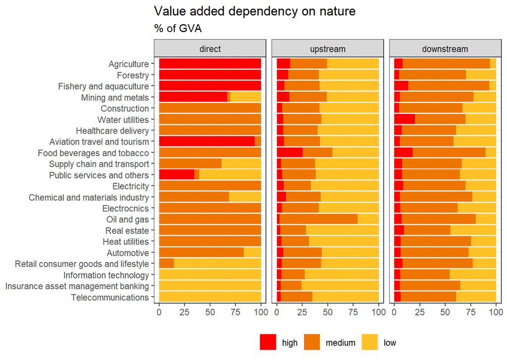

```r
# define the same sector order as H et al in their plot
sectord_gloria<-c("Agriculture","Forestry","Fishery and aquaculture",
           "Mining and metals","Construction","Water utilities",
           "Healthcare delivery","Aviation travel and tourism",
           "Food beverages and tobacco","Supply chain and transport",
           "Public services and others","Electricity",
           "Chemical and materials industry","Electrocnics","Oil and gas",
           "Real estate","Heat utilities","Automotive",
           "Retail consumer goods and lifestyle","Information technology",
           "Insurance asset management banking","Telecommunications")

# then the plot
pp<-dpd %>% filter(year==2020) %>% select(sector,scope,region,low,medium,high) %>%
  mutate(sector = factor(sector,levels = rev(sectord_gloria))) %>%
  group_by(sector,scope) %>% summarise(low = sum(low),medium = sum(medium),high=sum(high)) %>%
  pivot_longer(-c(sector,scope),names_to = "va_dependency",values_to = "share") %>%
  mutate(va_dependency = factor(va_dependency,levels=c("low","medium","high"))) %>%
  mutate(scope = factor(scope,levels=c("direct","upstream","downstream")))
ggplot(pp,aes(y=share,x=sector,fill=va_dependency)) + geom_bar(position="stack", stat="identity") +
  scale_fill_manual(values=c("goldenrod1","darkorange2","red"), guide = guide_legend(reverse = TRUE))+
  labs(title="Value added dependency on nature",
       subtitle = "% of GVA") +
  theme_bw() +
  coord_flip() +
  facet_wrap(~scope,nrow=1) +
  theme(legend.position = "bottom",
        legend.title = element_blank(),
        axis.title = element_blank())
```

### 5.1.2 EXIOBASE

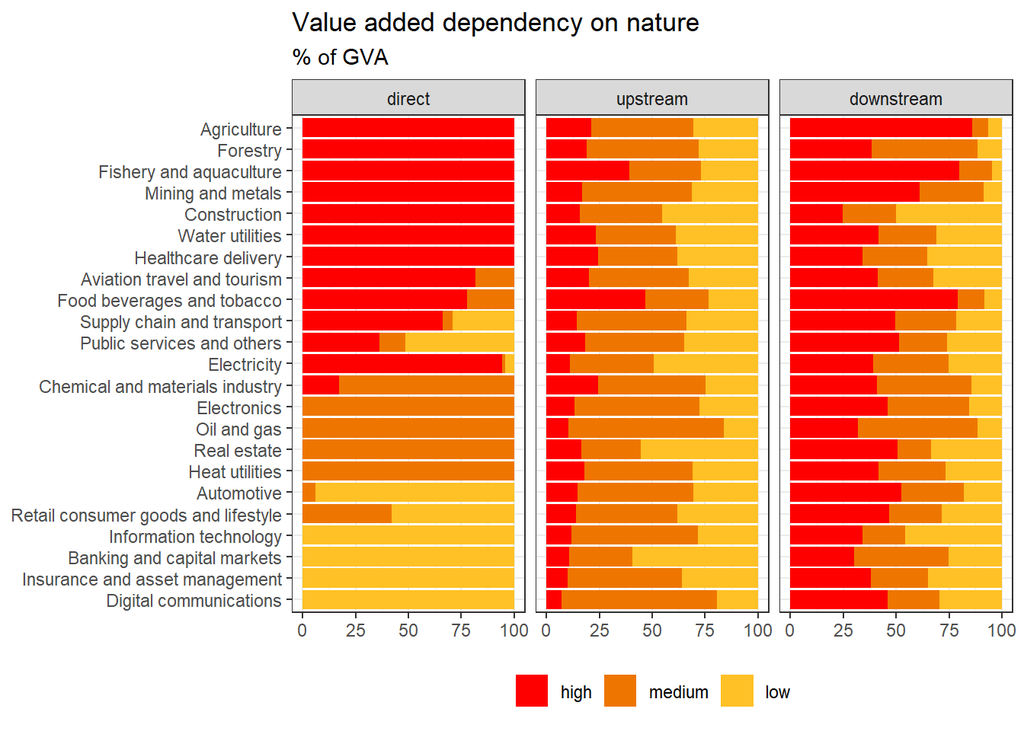

```r
# order of sectors to align with H et al
sectord_exio<-c("Agriculture","Forestry","Fishery and aquaculture",
           "Mining and metals","Construction","Water utilities",
           "Healthcare delivery","Aviation travel and tourism",
           "Food beverages and tobacco","Supply chain and transport",
           "Public services and others","Electricity",
           "Chemical and materials industry","Electronics","Oil and gas",
           "Real estate","Heat utilities","Automotive",
           "Retail consumer goods and lifestyle","Information technology",
           "Banking and capital markets","Insurance and asset management",
           "Digital communications")
# plot
pp<-dpde %>% filter(year==2022) %>% select(sector,scope,region,low,medium,high) %>%
  mutate(sector = factor(sector,levels = rev(sectord_exio))) %>%
  group_by(sector,scope) %>% summarise(low = sum(low),medium = sum(medium),high=sum(high)) %>%
  pivot_longer(-c(sector,scope),names_to = "va_dependency",values_to = "share") %>%
  mutate(va_dependency = factor(va_dependency,levels=c("low","medium","high"))) %>%
  mutate(scope = factor(scope,levels=c("direct","upstream","downstream")))
ggplot(pp,aes(y=share,x=sector,fill=va_dependency)) + geom_bar(position="stack", stat="identity") +
  scale_fill_manual(values=c("goldenrod1","darkorange2","red"), guide = guide_legend(reverse = TRUE))+
  labs(title="Value added dependency on nature",
       subtitle = "% of GVA") +
  theme_bw() +
  coord_flip() +
  facet_wrap(~scope,nrow=1) +
  theme(legend.position = "bottom",
        legend.title = element_blank(),
        axis.title = element_blank())
```

## 5.2 Results for 2020 by Region

### 5.2.1 GLORIA

Still for 2020.

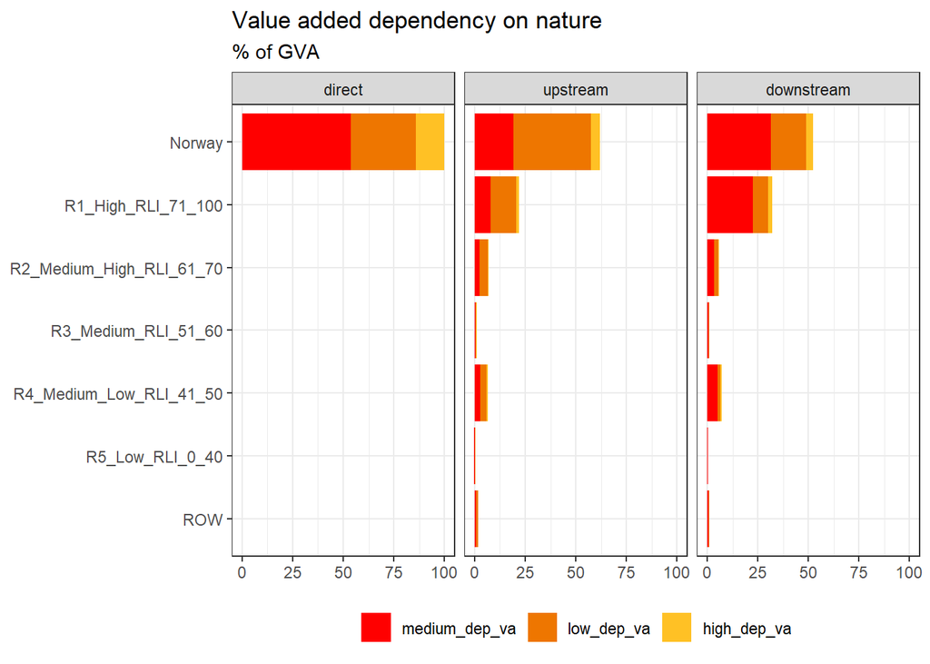

```r
rr<-dpd %>% filter(year==2020) %>% select(sector,scope,region,low_dep_va,medium_dep_va,high_dep_va) %>%
  group_by(scope,region) %>% summarise(low_dep_va=sum(low_dep_va),
                                       medium_dep_va=sum(medium_dep_va),
                                       high_dep_va=sum(high_dep_va)) %>%
  pivot_longer(-c(scope,region),names_to = "va_dependency",values_to = "va") %>%
  mutate(scope = factor(scope,levels=c("direct","upstream","downstream"))) %>%
  mutate(region = factor(region,levels = c("ROW","R5_Low_RLI_0_40",
                                           "R4_Medium_Low_RLI_41_50",
                                           "R3_Medium_RLI_51_60",
                                           "R2_Medium_High_RLI_61_70",
                                           "R1_High_RLI_71_100",
                                           "Norway")))
rr['va_byscope']<-NA
rr$va_byscope[rr$scope=="direct"]<-sum(rr$va[rr$scope=="direct"])
rr$va_byscope[rr$scope=="upstream"]<-sum(rr$va[rr$scope=="upstream"])
rr$va_byscope[rr$scope=="downstream"]<-sum(rr$va[rr$scope=="downstream"])
rr['va_share']<-100*rr$va/rr$va_byscope


ggplot(rr,aes(y=va_share,x=region,fill=va_dependency)) + geom_bar(position="stack", stat="identity") +
  scale_fill_manual(values=c("goldenrod1","darkorange2","red"), guide = guide_legend(reverse = TRUE))+
   labs(title="Value added dependency on nature",
       subtitle = "% of GVA") +
  theme_bw() +
  coord_flip() +
  facet_wrap(~ scope,nrow=1) +
  theme(legend.position = "bottom",
        legend.title = element_blank(),
        axis.title = element_blank())
```

### 5.2.3 EXIOBASE

Year is 2022.

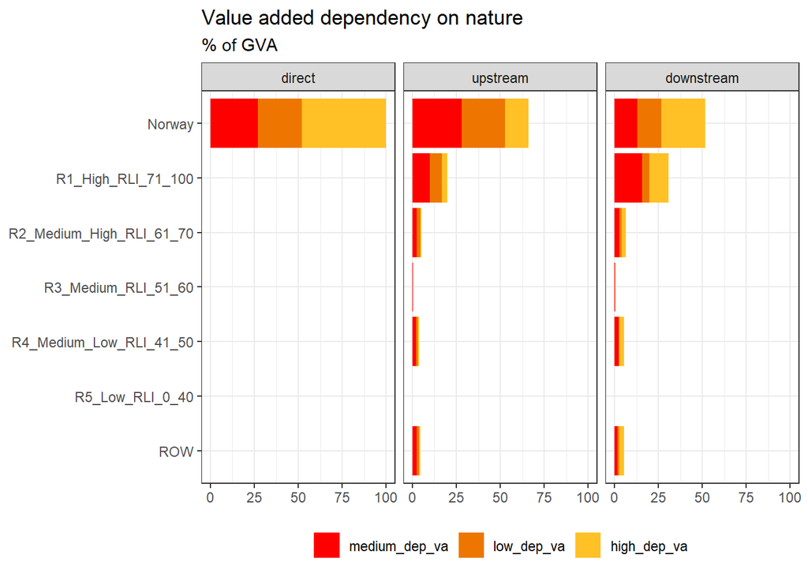

```r
rr<-dpde %>% filter(year==2022) %>% select(sector,scope,region,low_dep_va,medium_dep_va,high_dep_va) %>%
  group_by(scope,region) %>% summarise(low_dep_va=sum(low_dep_va),
                                       medium_dep_va=sum(medium_dep_va),
                                       high_dep_va=sum(high_dep_va)) %>%
  pivot_longer(-c(scope,region),names_to = "va_dependency",values_to = "va") %>%
  mutate(scope = factor(scope,levels=c("direct","upstream","downstream"))) %>%
  mutate(region = factor(region,levels = c("ROW","R5_Low_RLI_0_40",
                                           "R4_Medium_Low_RLI_41_50",
                                           "R3_Medium_RLI_51_60",
                                           "R2_Medium_High_RLI_61_70",
                                           "R1_High_RLI_71_100",
                                           "Norway")))
rr['va_byscope']<-NA
rr$va_byscope[rr$scope=="direct"]<-sum(rr$va[rr$scope=="direct"])
rr$va_byscope[rr$scope=="upstream"]<-sum(rr$va[rr$scope=="upstream"])
rr$va_byscope[rr$scope=="downstream"]<-sum(rr$va[rr$scope=="downstream"])
rr['va_share']<-100*rr$va/rr$va_byscope


ggplot(rr,aes(y=va_share,x=region,fill=va_dependency)) + geom_bar(position="stack", stat="identity") +
  scale_fill_manual(values=c("goldenrod1","darkorange2","red"), guide = guide_legend(reverse = TRUE))+
   labs(title="Value added dependency on nature",
       subtitle = "% of GVA") +
  theme_bw() +
  coord_flip() +
  facet_wrap(~ scope,nrow=1) +
  theme(legend.position = "bottom",
        legend.title = element_blank(),
        axis.title = element_blank())
```

## 5.3 Results over Time

Analysis over time so far only GLORIA-based.

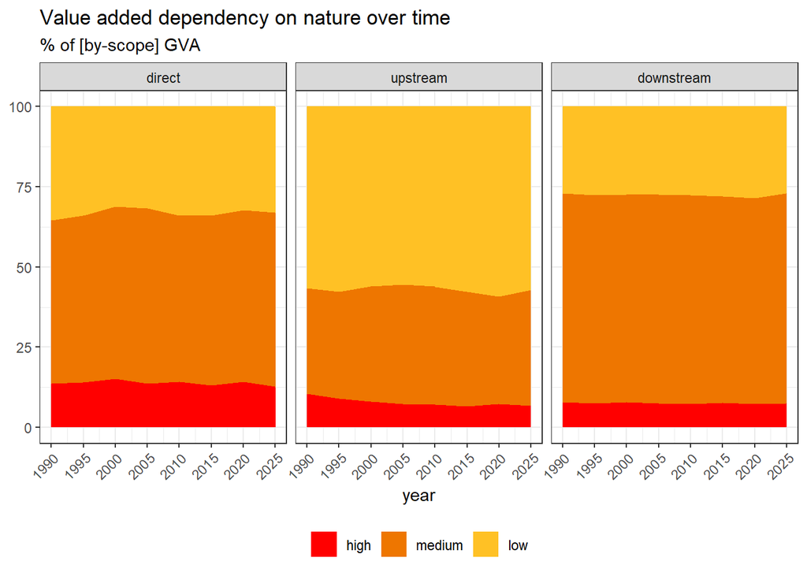

```r
tt<-dpd %>% select(year,sector,scope,low_dep_va,medium_dep_va,high_dep_va) %>%
  pivot_longer(-c(sector,scope,year),names_to = "va_dependency",values_to = "va") %>%
  group_by(year,scope,va_dependency) %>% summarise(va=sum(va)) %>%
  pivot_wider(names_from = va_dependency,values_from=va) %>%
  mutate(total=low_dep_va+medium_dep_va+high_dep_va) %>%
  mutate(low = 100*low_dep_va/total) %>%
  mutate(medium = 100*medium_dep_va/total) %>%
  mutate(high = 100*high_dep_va/total) %>%
  select(-c(low_dep_va,medium_dep_va,high_dep_va,total)) %>%
  pivot_longer(-c(year,scope),names_to = "va_dependency",values_to = "va") %>%
  mutate(va_dependency = factor(va_dependency,levels=c("low","medium","high"))) %>%
  mutate(scope = factor(scope,levels=c("direct","upstream","downstream")))

ggplot(tt,aes(y=va,x=year,fill=va_dependency)) + geom_area() +
  scale_fill_manual(values=c("goldenrod1","darkorange2","red"),
                    guide = guide_legend(reverse = TRUE))+
  labs(title="Value added dependency on nature over time",
       subtitle="% of [by-scope] GVA") +
  scale_x_continuous(breaks = unique(tt$year))+
  theme_bw() +
  facet_wrap(~scope,nrow=1) +
  theme(legend.position = "bottom",
        legend.title = element_blank(),
        axis.title.y = element_blank(),
        axis.text.x = element_text(angle = 45, hjust = 1))
```

And one more, disgaggregated by region

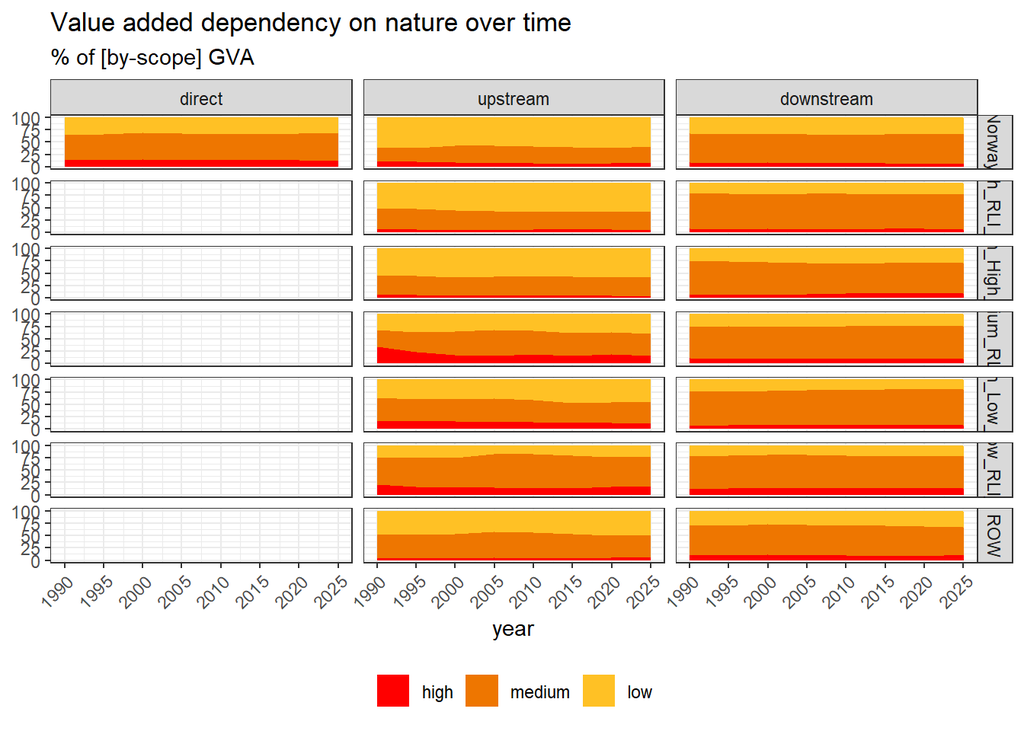

```r
tr<-dpd %>% select(year,sector,scope,region,low_dep_va,medium_dep_va,high_dep_va) %>%
  pivot_longer(-c(sector,scope,region,year),names_to = "va_dependency",values_to = "va") %>%
  group_by(year,scope,va_dependency,region) %>% summarise(va=sum(va)) %>%
  pivot_wider(names_from = va_dependency,values_from=va) %>%
  mutate(total=low_dep_va+medium_dep_va+high_dep_va) %>%
  mutate(low = 100*low_dep_va/total) %>%
  mutate(medium = 100*medium_dep_va/total) %>%
  mutate(high = 100*high_dep_va/total) %>%
  select(-c(low_dep_va,medium_dep_va,high_dep_va,total)) %>%
  pivot_longer(-c(year,scope,region),names_to = "va_dependency",values_to = "va") %>%
  mutate(va_dependency = factor(va_dependency,levels=c("low","medium","high"))) %>%
  mutate(scope = factor(scope,levels=c("direct","upstream","downstream")))

ggplot(tr,aes(y=va,x=year,fill=va_dependency)) + geom_area() +
  scale_fill_manual(values=c("goldenrod1","darkorange2","red"),
                    guide = guide_legend(reverse = TRUE))+
  labs(title="Value added dependency on nature over time",
       subtitle="% of [by-scope] GVA") +
  scale_x_continuous(breaks = unique(tr$year))+
  theme_bw() +
  facet_grid(region~scope) +
  theme(legend.position = "bottom",
        legend.title = element_blank(),
        axis.title.y = element_blank(),
        axis.text.x = element_text(angle = 45, hjust = 1))
```

# 6. Next Steps